# Assignment 1

In this assignment, we conduct a simple analysis on the data of the number of steps taken per 5-minute interval by an anonymous person.

First, we load the dataset.

```r
data <- read.csv('activity.csv')
```

## Total Steps per Day

We take a brief look at the data.

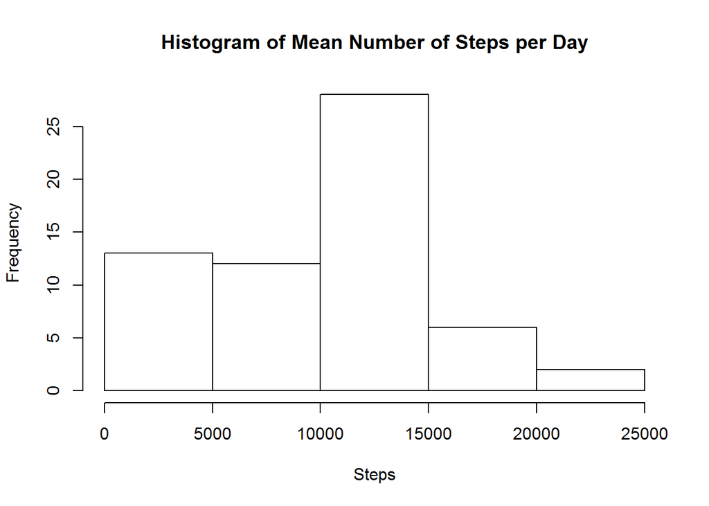

```r
sums <- tapply(data$steps,data$date,sum,na.rm=T)
    hist(sums,main='Histogram of Mean Number of Steps per Day',xlab='Steps')
```

```r
mean <- mean(sums)
med <- median(sums)
```

The mean and median of the total number of steps taken per day are 9354.2295082 and 10395 respectively.

## Daily Walking Pattern

It may be interesting looking at the person’s daily walking pattern.

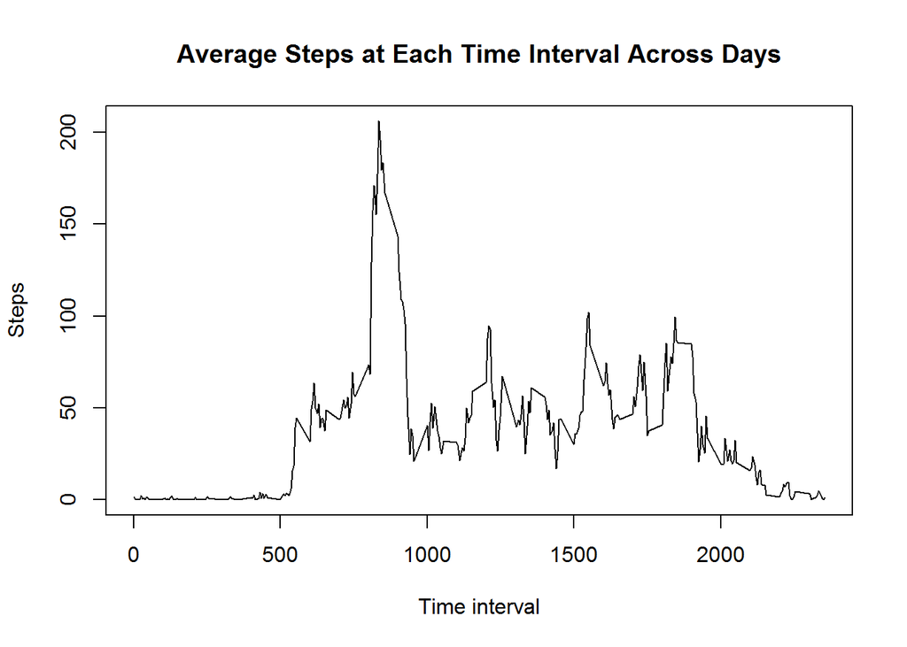

```r
avg.per.interval <- tapply(data$steps,data$interval,mean,na.rm=T)
intervals <- unique(data$interval)

plot(avg.per.interval~intervals, type='l',ylab='Steps', xlab='Time interval',
     main='Average Steps at Each Time Interval Across Days')
```

We can see that the person is most active at around 8am to 9am, which is most likely because of commuting to work/school.

```r
maximum <- intervals[which(avg.per.interval==max(avg.per.interval))]
max.int <- formatC(maximum,width=4,flag='0')
max.int <- strftime(strptime(max.int,format='%H%M'),format='%H:%M')
```

The time with the most steps taken is precisely the 5-minute interval staring at 08:35.

## Impute Missing Data

As we can see, there are quite a few missing values in the data, however, which might have made the previous analyses biased.

```r
head(data)
```

```
##   steps       date interval
## 1    NA 2012-10-01        0
## 2    NA 2012-10-01        5
## 3    NA 2012-10-01       10
## 4    NA 2012-10-01       15
## 5    NA 2012-10-01       20
## 6    NA 2012-10-01       25
```

```r
na <- unique(c(which(is.na(data$step)),which(is.na(data$interval)),
               which(is.na(data$date))))
no.na <- length(na)
```

There are 2304 rows with missing values, which is not a negligible number.

Therefore, we impute the missing values and see what happens. A reasonable way to do so would be to use the average number of steps for each interval as a substitute.

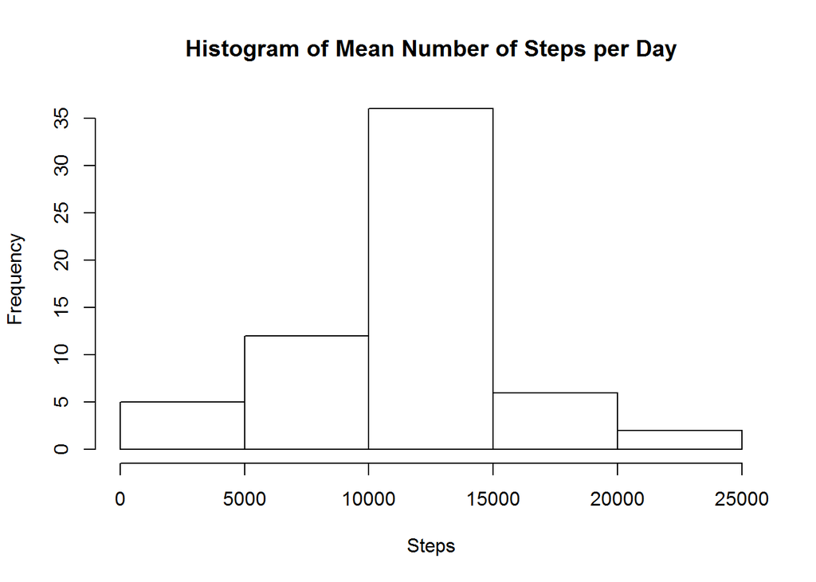

```r
#impute data
simulated <- rep(avg.per.interval,length.out=length(data$steps))
    data[na,'steps'] <- simulated[na]

#see how the histogram, mean and median have changed
sums <- tapply(data$steps,data$date,sum,na.rm=T)
hist(sums,main='Histogram of Mean Number of Steps per Day',xlab='Steps')
```

```r
mean2 <- mean(sums)
med2 <- median(sums)
```

[output not shown]

## Comparison Between Weekdays and Weekends

We may also be curious about the differences of walking patterns between weekdays and weekends. Below is a graphical comparison.

```r
#create factore variable with levels weekday and weekend
weekday <- weekdays(strptime(data$date,format='%Y-%m-%d'))

days <- rep('weekday',length.out=length(data$date))
days[weekday == 'Sunday'|weekday =='Saturday'] <- 'weekend'
days <- factor(days,levels=c('weekday','weekend'))

#Merge the factor variable into the data
library(dplyr)
```

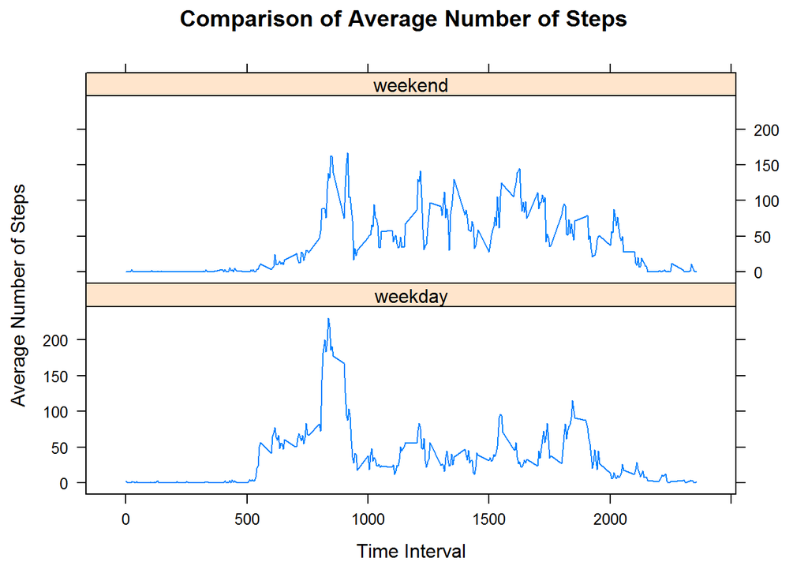

```r
data <- mutate(data,w.day.or.w.end=days)

#Calculate the average for each interval for weekdays and weekends separately
data2 <- group_by(select(data,-date),w.day.or.w.end,interval)
avgSteps <- summarise(data2,avg=mean(steps))

#Plot graph
library(lattice)
xyplot(avg~interval|w.day.or.w.end,data=avgSteps,type='l',layout=c(1,2),
       ylab='Average Number of Steps',xlab='Time Interval',
       main='Comparison of Average Number of Steps')
```

We notice that the person’s walking activity is spread more evenly across the day during weekends, and more centered around the standard commuting time (8am - 9am) during weekdays.